# M3T2:

Chioma Anozie

2023-04-17

```r
library(readr)
library(funModeling)
library(tidyverse)
library(Hmisc)
library(reshape)
library(caret)
library(mlbench)
```

```r
library(cowplot)
library(dbplyr)
library(dplyr)
library(dtplyr)
library(forcats)
library(gbm)
library(GGally)
library(ggplot2)
library(pacman)
library(gridExtra)
library(grid)
```

# Introduction

You have been asked by Danielle Sherman, CTO of Blackwell Electronics, to predict the customers’ brand preferences that are missing from the incomplete surveys by conducting two classification methods in R. Once you have determined which classifier —C5.0 or RandomForest —works better on the provided data set, she would like you to predict the brand preferences for the incomplete survey responses and prepare a report of your findings.

**This task requires you to prepare one deliverable for Danielle Sherman:**

- *Customer Brand Preferences Report.* A report in a Zip file that includes:
  - A brief summary in Word or Excel of your methods and results that includes:
    - The classifiers you tried.
    - The classifier you selected to make the predictions, including a rationale for selecting the method you did and the level of confidence in the predictions.
    - The predicted answers to the brand preference question for the instances of survey results that are missing that answer.
    - A chart that displays the customer preference for each brand based on the combination of the actual answers and the predicted answers to the brand preference survey question.
  - The results of each classifier you ran exported from R

# Extracting and Cleaning Data

Before performing EDA on the dataset, I will first extract the data and clean it up, if necessary

```r
completeResponses_Data <- read.csv(file = './SurveyData/CompleteResponses.csv')
```

```r
basic_eda <- function(data)
{
  glimpse(data)
  df_status(data)
  freq(data)
  profiling_num(data)
  plot_num(data)
  describe(data)
}
```

This is created to do some basic EDA on a dataset passed into it, as an argument.

```r
#rowSums(is.na(completeResponsesData)) # Number of missing per row
nrow(completeResponses_Data[duplicated(completeResponses_Data),])
```

```
## [1] 0
```

```r
#CompleteResponsesData$elevel <- as.factor(CompleteResponsesData$elevel)
completeResponses_Data$car <- as.factor(completeResponses_Data$car)
completeResponses_Data$zipcode <- as.factor(completeResponses_Data$zipcode)
completeResponses_Data$brand <- as.factor(completeResponses_Data$brand)
completeResponses_Data$elevel <- ordered(completeResponses_Data$elevel, levels = c(0,1,2,3,4))
```

I checked for any missing data in the dataset and it returned zero. This makes it easy to proceed to the next step.

```r
names(completeResponses_Data)<-c("salary","age","education_level","car","zipcode","credit","computer_brand")
```

Changing the names of the headings of each data column to make it easier to manipulate the dataset with code.

```r
completeResponses_Data$education_level<-factor(completeResponses_Data$education_level,labels=c("Lower than High School Degree","High School Degree","Some College","4-Year College DegreeI","Master's, Doctoral or Professional Degree"),ordered=TRUE)

completeResponses_Data$car<-factor(completeResponses_Data$car,labels=c("BMW","Buick"," Cadillac","Chevrolet","Chrysler","Dodge","Ford","Honda","Hyundai","Jeep","Kia","Lincoln","Mazda","Mercedes Benz","Mitsubishi", "Nissan","Ram","Subaru","Toyota","None of the above"),ordered=TRUE)

completeResponses_Data$zipcode<-factor(completeResponses_Data$zipcode,labels=c("New England","Mid-Atlantic","East North Central","West North Central","South Atlantic", "East South Central" , "West South Central","Mountain","Pacific"),ordered=TRUE)

completeResponses_Data$computer_brand<-factor(completeResponses_Data$computer_brand,labels=c("Acer","Sony"),ordered=TRUE)
```

Changing the data type of specific columns in the dataset, due to the nature of data contained therein.

```r
basic_eda(completeResponses_Data)
```

```
## Rows: 9,898
## Columns: 7
## $ salary          <dbl> 119806.54, 106880.48, 78020.75, 63689.94, 50873.62, 13…
## $ age             <int> 45, 63, 23, 51, 20, 56, 24, 62, 29, 41, 48, 52, 52, 33…
## $ education_level <ord> "Lower than High School Degree", "High School Degree",…
## $ car             <ord> Mercedes Benz, Kia, Mitsubishi, Dodge, Mercedes Benz, …
## $ zipcode         <ord> South Atlantic, West South Central, East North Central…
## $ credit          <dbl> 442037.71, 45007.18, 48795.32, 40888.88, 352951.50, 13…
## $ computer_brand  <ord> Acer, Sony, Acer, Sony, Acer, Sony, Sony, Sony, Acer, …
##          variable q_zeros p_zeros q_na p_na q_inf p_inf           type unique
## 1          salary       0     0.0    0    0     0     0        numeric   9656
## 2             age       0     0.0    0    0     0     0        integer     61
## 3 education_level       0     0.0    0    0     0     0 ordered-factor      5
## 4             car       0     0.0    0    0     0     0 ordered-factor     20
## 5         zipcode       0     0.0    0    0     0     0 ordered-factor      9
## 6          credit     119     1.2    0    0     0     0        numeric   9652
## 7  computer_brand       0     0.0    0    0     0     0 ordered-factor      2
```

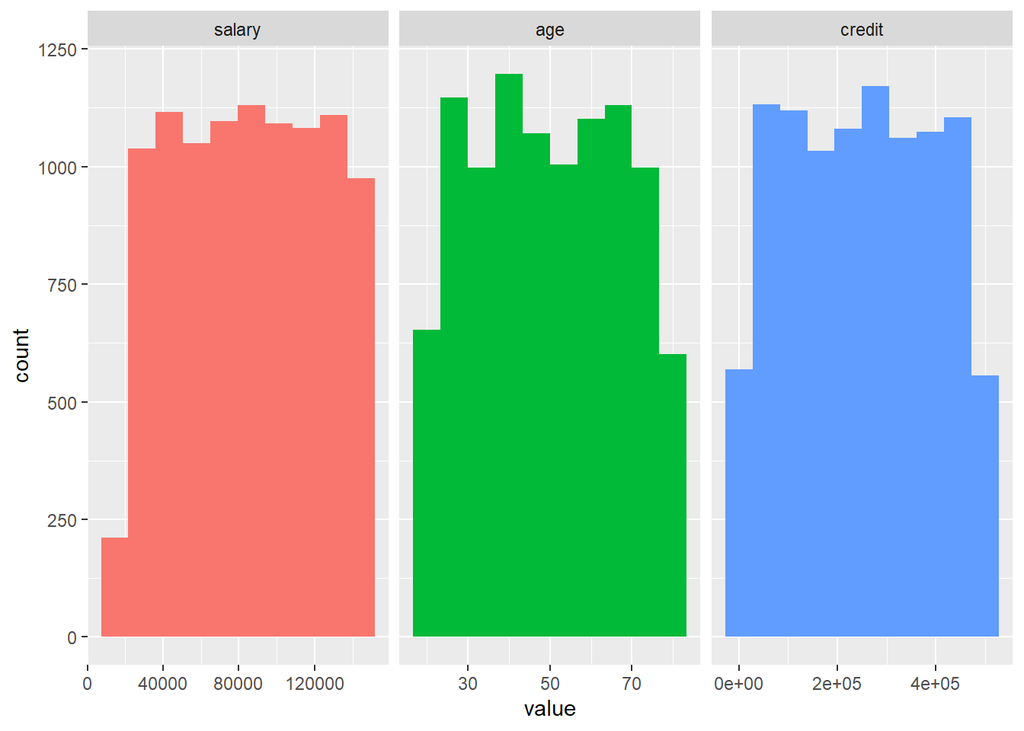

```
## data
##
##  7  Variables      9898  Observations
## --------------------------------------------------------------------------------
## salary
##        n  missing distinct     Info     Mean      Gmd      .05      .10
##     9898        0     9656        1    84871    43547    25984    32495
##      .25      .50      .75      .90      .95
##    52082    84950   117162   137038   143291
##
## lowest :  20000.00  20105.59  20140.31  20218.82  20224.66
## highest: 149919.44 149964.88 149973.46 149994.21 150000.00
## --------------------------------------------------------------------------------
## age
##        n  missing distinct     Info     Mean      Gmd      .05      .10
##     9898        0       61        1    49.78    20.32       23       26
##      .25      .50      .75      .90      .95
##       35       50       65       74       77
##
## lowest : 20 21 22 23 24, highest: 76 77 78 79 80
## --------------------------------------------------------------------------------
## education_level
##        n  missing distinct
##     9898        0        5
##
## lowest : Lower than High School Degree             High School Degree                        Some College                              4-Year College DegreeI                    Master's, Doctoral or Professional Degree
## highest: Lower than High School Degree             High School Degree                        Some College                              4-Year College DegreeI                    Master's, Doctoral or Professional Degree
## --------------------------------------------------------------------------------
## car
##        n  missing distinct
##     9898        0       20
##
## lowest : BMW               Buick              Cadillac         Chevrolet         Chrysler
## highest: Nissan            Ram               Subaru            Toyota            None of the above
## --------------------------------------------------------------------------------
## zipcode
##        n  missing distinct
##     9898        0        9
##
## lowest : New England        Mid-Atlantic       East North Central West North Central South Atlantic
```

[output cut: 9 more lines]

```
##     9898        0     9652        1   249176   167677    24173    48829
##      .25      .50      .75      .90      .95
##   120807   250607   374640   449383   475295
##
## lowest :      0.00000     25.27104    101.36103    167.51472    283.89827
## highest: 499791.41690 499805.50660 499873.91900 499919.02330 500000.00000
## --------------------------------------------------------------------------------
## computer_brand
##        n  missing distinct
##     9898        0        2
##
## Value       Acer  Sony
## Frequency   3744  6154
## Proportion 0.378 0.622
## --------------------------------------------------------------------------------
```

Performing basic EDA on the completeResponses Dataset, to note the mean, datatype, highest, lowest et al. This will be later used to compare with EDA performed on the incomplete dataset “surveyIncomplete” after prediction has been done and the computer_brands column of surveyIncomplete has been replaced with more accurate data.

```r
head(completeResponses_Data)
```

```
##      salary age               education_level           car            zipcode
## 1 119806.54  45 Lower than High School Degree Mercedes Benz     South Atlantic
## 2 106880.48  63            High School Degree           Kia West South Central
## 3  78020.75  23 Lower than High School Degree    Mitsubishi East North Central
## 4  63689.94  51        4-Year College DegreeI         Dodge East South Central
## 5  50873.62  20        4-Year College DegreeI Mercedes Benz     South Atlantic
## 6 130812.74  56        4-Year College DegreeI Mercedes Benz West North Central
##      credit computer_brand
## 1 442037.71           Acer
## 2  45007.18           Sony
## 3  48795.32           Acer
## 4  40888.88           Sony
## 5 352951.50           Acer
## 6 135943.02           Sony
```

```r
#completeResponses_Data <- subset(completeResponses_Data, select = -c(education))
```

```r
completeResponses_Data$salary -> salary
completeResponses_Data$age -> age
completeResponses_Data$education_level -> education_level
completeResponses_Data$car -> car
completeResponses_Data$zipcode -> zipcode
completeResponses_Data$credit -> credit
completeResponses_Data$computer_brand -> computer_brand
```

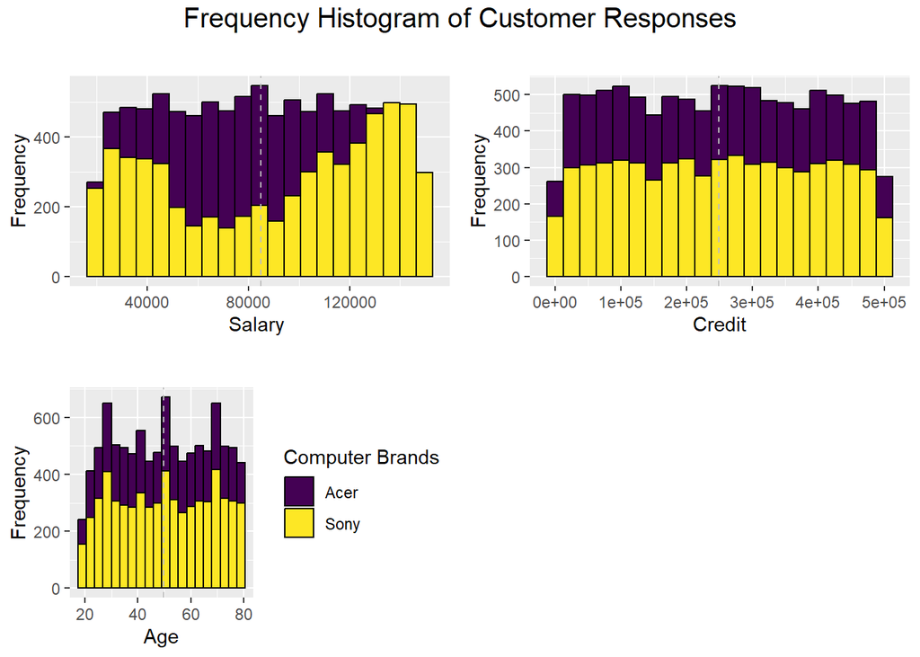

```r
# Density & Frequency analysis with the Histogram,

# salary
HisS <- ggplot(data=completeResponses_Data, aes(x=salary))+
  geom_histogram(binwidth=6500, color="black", aes(fill=computer_brand)) +
  xlab("Salary ") +
  ylab("Frequency") +
  theme(legend.position="none")+
  ggtitle("Histogram of Salary")+
  geom_vline(data=completeResponses_Data, aes(xintercept = mean(salary)),linetype="dashed",color="grey")


# Credit
HistCr <- ggplot(data=completeResponses_Data, aes(x=credit)) +
  geom_histogram(binwidth=25000, color="black", aes(fill=computer_brand)) +
  xlab("Credit") +
  ylab("Frequency") +
  theme(legend.position="none")+
  ggtitle("Histogram of Credit")+
  geom_vline(data=completeResponses_Data, aes(xintercept = mean(credit)),linetype="dashed",color="grey")


# Age
HistAg <- ggplot(data=completeResponses_Data, aes(x=age))+
  geom_histogram(bins=20, color="black", aes(fill=computer_brand)) +
  xlab("Age") +
  ylab("Frequency") +
  theme(legend.position="right" )+
 guides(fill=guide_legend('Computer Brands'))+
  ggtitle("Histogram of Age")+
  geom_vline(data=completeResponses_Data, aes(xintercept = mean(age)),
             linetype="dashed",color="grey")






# Plot all visualizations
grid.arrange(HisS + ggtitle(""),
             HistCr + ggtitle(""),
             HistAg + ggtitle(""),
             #HistPw  + ggtitle(""),
             nrow = 2,
             top = textGrob("Frequency Histogram of Customer Responses",
                            gp=gpar(fontsize=15) )

)
```

From the plots above, it can be deduced that a higher percentage of customers buy the Sony brand. It can also be seen that customers with high and low salaries prefer to purchase Sony, while customers with mid-income ranges prefer to purchase Acer.

This can be explained thus: Customers with higher salaries can afford the Sony, while customers with low income prefer Sony because it lasts longer and maybe because it helps them identify with high-income earners. However, I will need more data to verfiy my assumptions.

Its also notable that across all ages, Sony is purchased more.

```r
bin_labels_10 <- c("19/33K", "33/46K", "46/59K", "59/72K", "72/85K", "85/98K", "98/111K", "111/124K", "124/137K", "137/150K")
```

```r
completeResponses_Data$salary_bin <- cut(completeResponses_Data$salary, breaks=quantile(completeResponses_Data$salary, probs=seq(0,1,0.1)), labels=bin_labels_10, include.lowest=TRUE)
table(completeResponses_Data$salary_bin)
```

```
##
##   19/33K   33/46K   46/59K   59/72K   72/85K   85/98K  98/111K 111/124K
##      990      990      990      989      990      990      989      990
## 124/137K 137/150K
##      990      990
```

```r
head(completeResponses_Data, 10)
```

```
##       salary age                           education_level           car
## 1  119806.54  45             Lower than High School Degree Mercedes Benz
## 2  106880.48  63                        High School Degree           Kia
## 3   78020.75  23             Lower than High School Degree    Mitsubishi
## 4   63689.94  51                    4-Year College DegreeI         Dodge
## 5   50873.62  20                    4-Year College DegreeI Mercedes Benz
## 6  130812.74  56                    4-Year College DegreeI Mercedes Benz
## 7  136459.34  24 Master's, Doctoral or Professional Degree         Honda
## 8  103866.90  62                    4-Year College DegreeI      Cadillac
## 9   72298.80  29 Master's, Doctoral or Professional Degree           Ram
## 10  37803.33  41                        High School Degree      Chrysler
##               zipcode    credit computer_brand salary_bin
## 1      South Atlantic 442037.71           Acer   111/124K
## 2  West South Central  45007.18           Sony    98/111K
## 3  East North Central  48795.32           Acer     72/85K
## 4  East South Central  40888.88           Sony     59/72K
## 5      South Atlantic 352951.50           Acer     46/59K
## 6  West North Central 135943.02           Sony   124/137K
## 7  East South Central  80500.56           Sony   124/137K
## 8         New England 359803.89           Sony    98/111K
## 9         New England 276298.70           Acer     72/85K
## 10     South Atlantic 493219.27           Sony     33/46K
```

```r
salary_bin <- completeResponses_Data$salary_bin
```

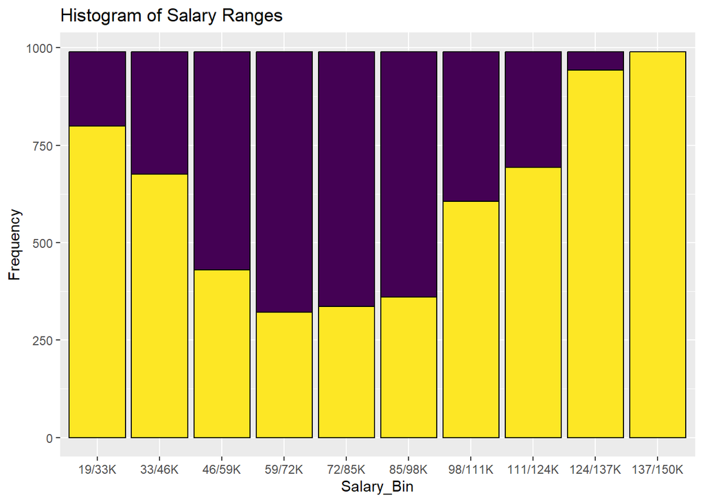

```r
HistAS <- ggplot(data=completeResponses_Data, aes(x=salary_bin)) +
  geom_histogram(color="black", aes(fill=computer_brand), stat = 'count') +
  xlab("Salary_Bin") +
  ylab("Frequency") +
  theme(legend.position="none")+
  ggtitle("Histogram of Salary Ranges")+
  geom_vline(data=completeResponses_Data, aes(xintercept = mean(salary)),linetype="dashed",color="grey")
HistAS
```

```r
completeResponses_Data <- subset(completeResponses_Data, select = -c(salary_bin))
```

I created salary_bin, to see if I can deduce any specific preferences of computer brand based on salary scale. After plotting frequency of salary_bin histogram, I noticed my histogram is very simple to the salary histogram. Hence I discarded the salary_bin column as it appeared not to have much of an impact on my deductions.

My previous deductions still stands: High income earners have a strong preference for purchasing the Sony brand, followed by Low income earners.

Next, I will start performing analysis on single variables and multiple variables for further insights on the available data.

# EDA

## EDA: Comparing Single Variables

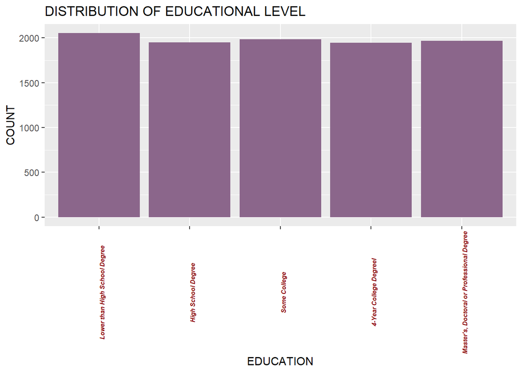

```r
# Distribution of education level
#elevel<-factor(completeResponses_Data$elevel, ordered=TRUE)
ggplot(completeResponses_Data, aes(education_level))+ geom_bar(fill="plum4")+labs(title = "DISTRIBUTION OF EDUCATIONAL LEVEL", x = "EDUCATION", y = "COUNT")+ theme(axis.text.x = element_text(face = "bold.italic", color = "red4",size = 6,angle = 90))
```

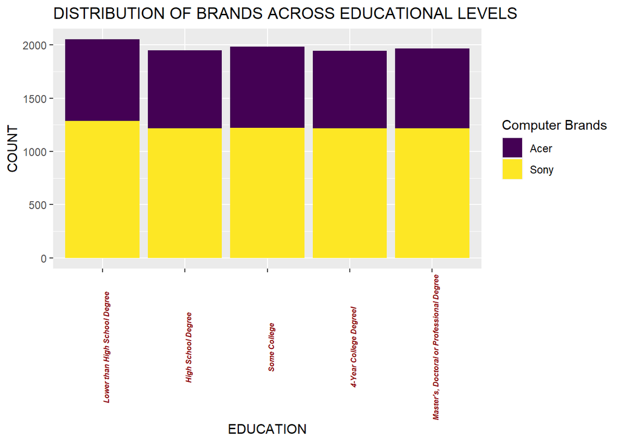

```r
# Distribution of brands across education levels
#elevel<-factor(completeResponses_Data$elevel, ordered=TRUE)
ggplot(completeResponses_Data, aes(education_level))+ geom_bar(aes(fill=computer_brand))+labs(title = "DISTRIBUTION OF BRANDS ACROSS EDUCATIONAL LEVELS", x = "EDUCATION", y = "COUNT")+ theme(axis.text.x = element_text(face = "bold.italic", color = "red4",size = 6,angle = 90))+ guides(fill=guide_legend('Computer Brands'))
```

From the graphs above, it can be seen that across all education levels, Sony is the preference brand of choice.

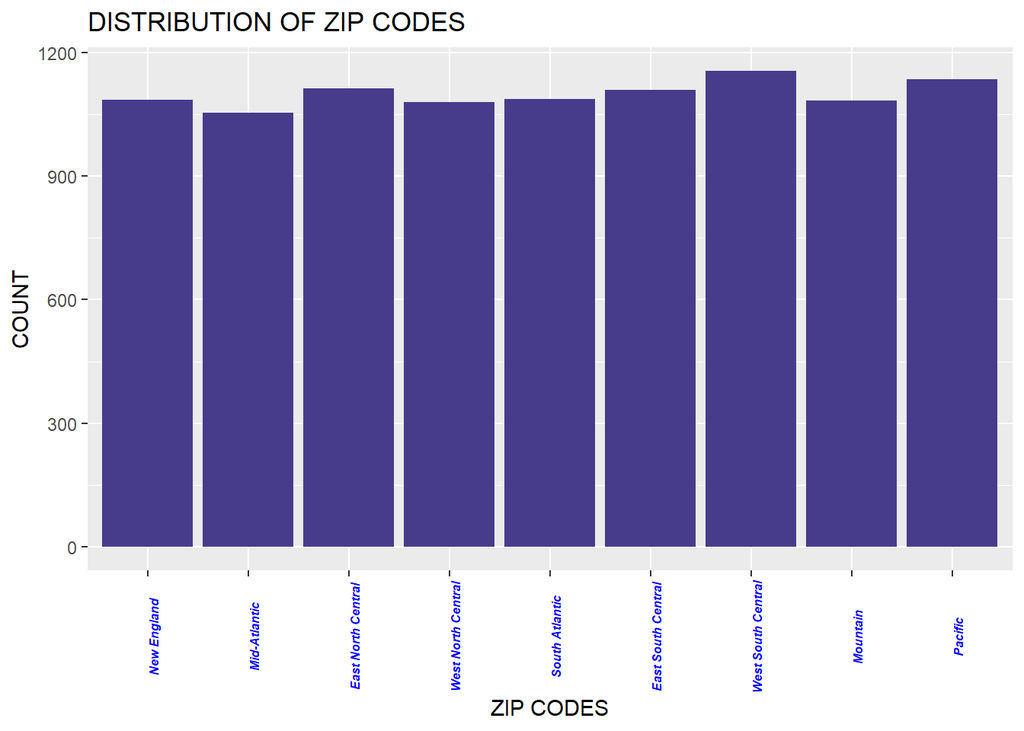

```r
# Distribution of education level

ggplot(completeResponses_Data, aes(zipcode))+ geom_bar(fill="slateblue4")+labs(title = "DISTRIBUTION OF ZIP CODES", x = "ZIP CODES", y = "COUNT")+ theme(axis.text.x = element_text(face = "bold.italic", color = "blue",size = 6,angle = 90))
```

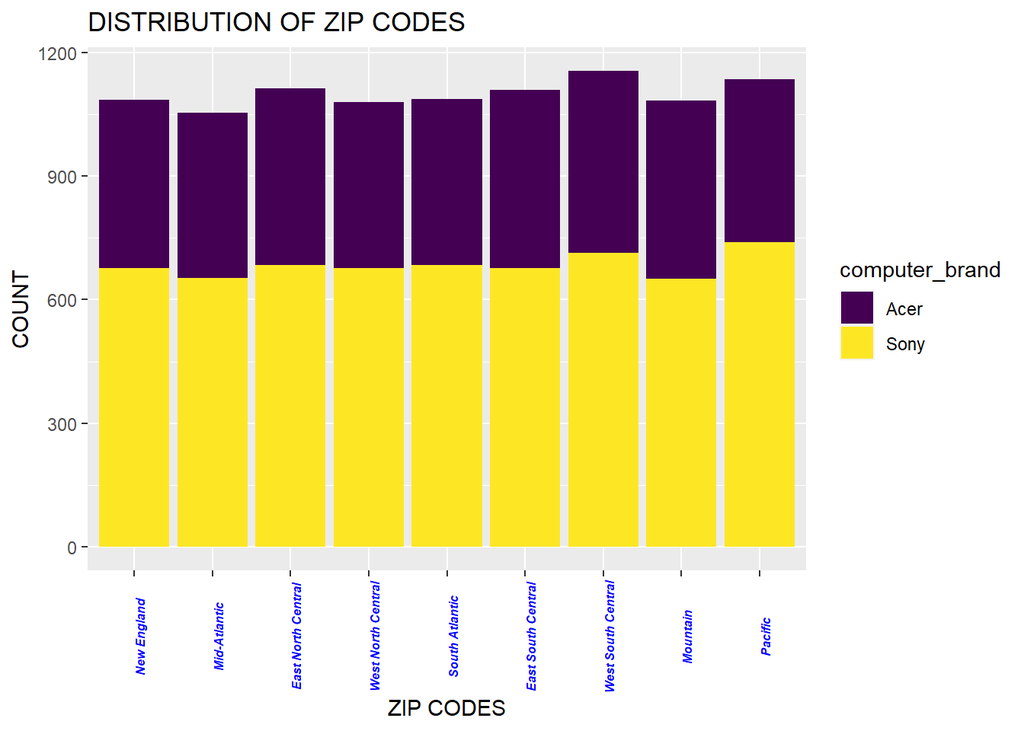

```r
ggplot(completeResponses_Data, aes(zipcode))+ geom_bar(aes(fill=computer_brand))+labs(title = "DISTRIBUTION OF ZIP CODES", x = "ZIP CODES", y = "COUNT")+ theme(axis.text.x = element_text(face = "bold.italic", color = "blue",size = 6,angle = 90))
```

The graphs above aim to determine if zipcode is a strong determinant of the computer brand purchased. And the graphs prove that zipcode does not affect the brand purchased, as most customers from all the zipcodes have a strong preference for Sony.

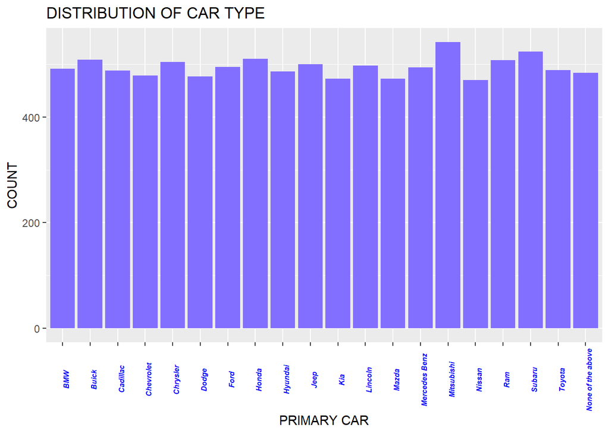

```r
ggplot(completeResponses_Data, aes(car))+ geom_bar(fill="slateblue1")+labs(title = "DISTRIBUTION OF CAR TYPE", x = "PRIMARY CAR", y = "COUNT")+ theme(axis.text.x = element_text(face = "bold.italic", color = "blue",size = 6,angle = 90))
```

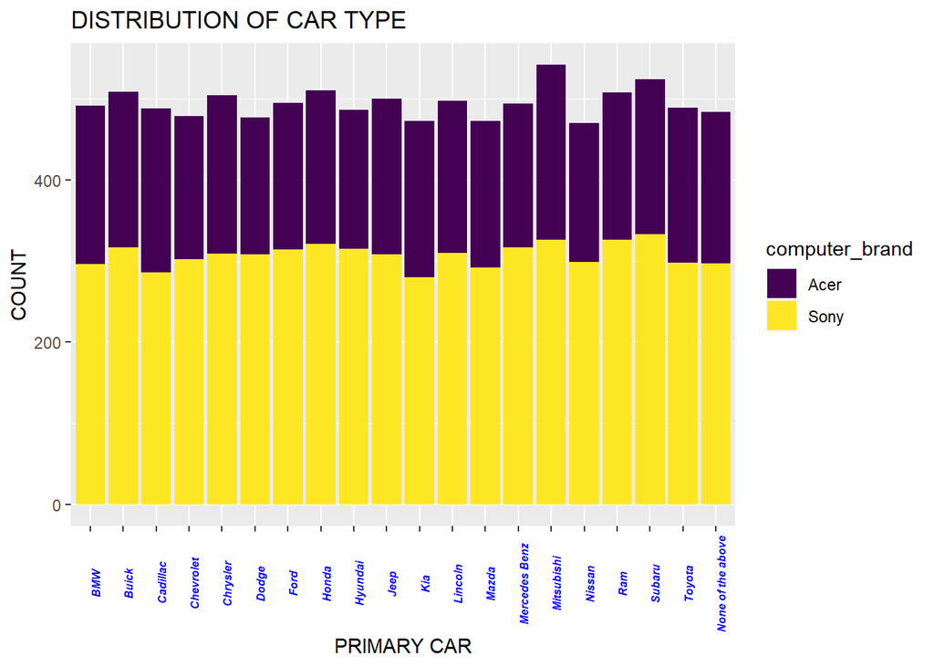

```r
ggplot(completeResponses_Data, aes(car))+ geom_bar(aes(fill=computer_brand))+labs(title = "DISTRIBUTION OF CAR TYPE", x = "PRIMARY CAR", y = "COUNT")+ theme(axis.text.x = element_text(face = "bold.italic", color = "blue",size = 6,angle = 90))
```

Does the car the customer drives, determine their taste in computer brands? The graphs above show that the computer brand purchased is not determined by the type of car the customer drives. Again across all car brands, sony is the highest purchased computer brand.

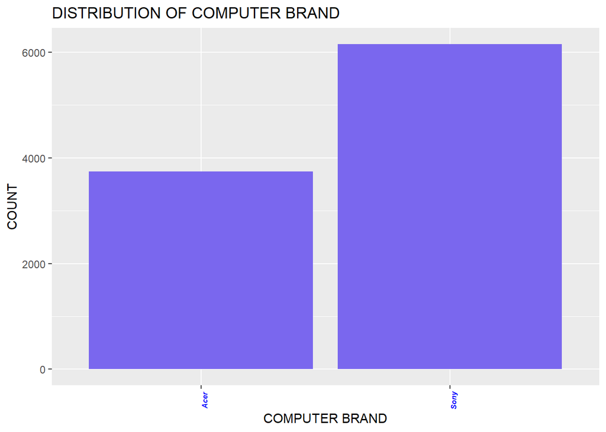

```r
ggplot(completeResponses_Data, aes(computer_brand))+ geom_bar(fill="slateblue2")+labs(title = "DISTRIBUTION OF COMPUTER BRAND", x = "COMPUTER BRAND", y = "COUNT")+ theme(axis.text.x = element_text(face = "bold.italic", color = "blue",size = 6,angle = 90))
```

Deductions so far:

Salary earned determines the computer brand purchased. Zipcode, Education level and Car brand does not determine the computer brand purchased.

Next we do Multi-variable analysis.

## EDA: Comparing multiple variables

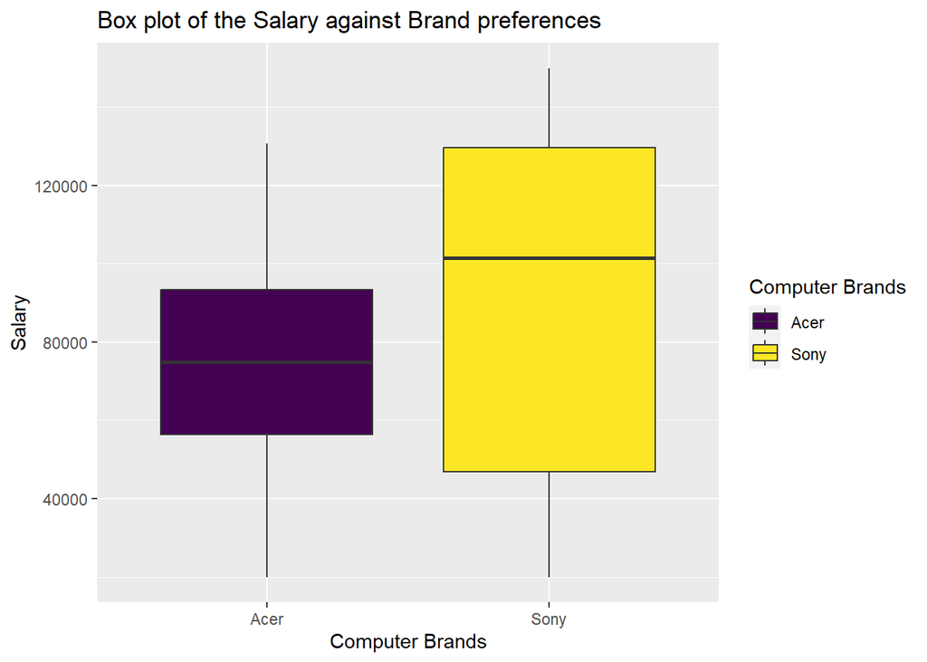

```r
ggplot(completeResponses_Data, aes(x = computer_brand, y = salary, fill = computer_brand)) +
  geom_boxplot() +
  labs(title = "Box plot of the Salary against Brand preferences", y = "Salary", x = "Computer Brands") +
  theme(legend.position="right" )+
  guides(fill=guide_legend('Computer Brands'))
```

From the boxplot above, we can see that Sony has a higher average of purchases from high income customers, while Acer is on average, bought from a mostly middle-income earners. This further confirms our deductions from the previous section.

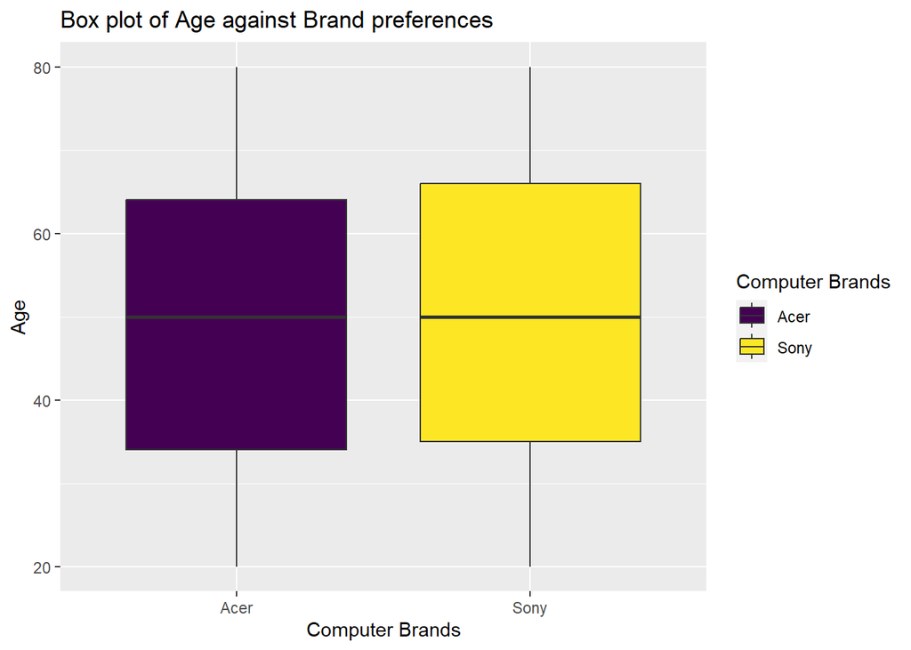

```r
ggplot(completeResponses_Data, aes(x = computer_brand, y = age, fill = computer_brand)) +
  geom_boxplot() +
  labs(title = "Box plot of Age against Brand preferences", y = "Age", x = "Computer Brands") +
  theme(legend.position="right" )+ guides(fill=guide_legend('Computer Brands'))
```

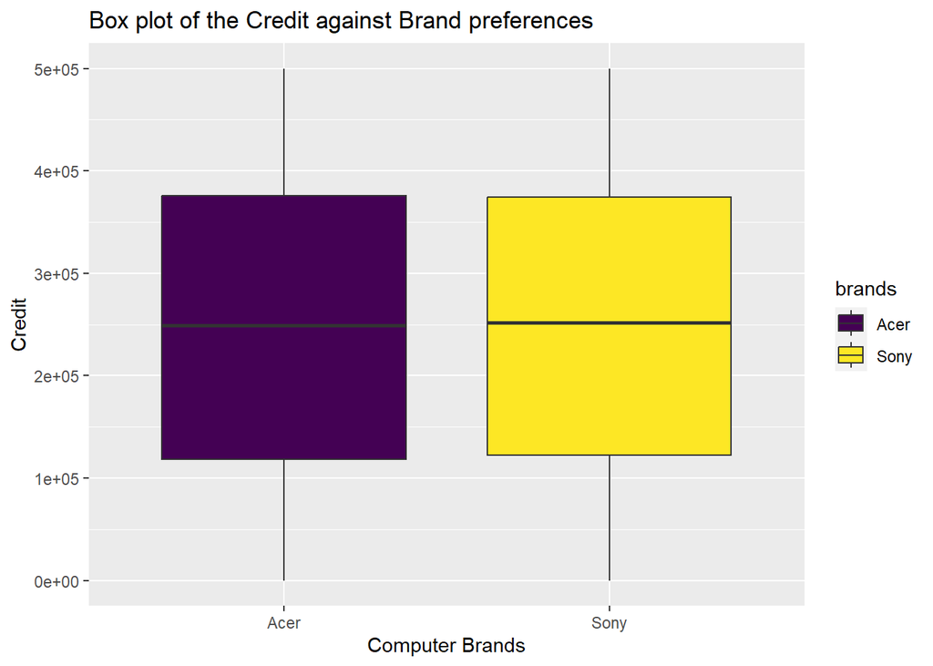

```r
ggplot(completeResponses_Data, aes(x = computer_brand, y = credit, fill = computer_brand)) +
  geom_boxplot() +
  labs(title = "Box plot of the Credit against Brand preferences", y = "Credit", x = "Computer Brands")+ guides(fill=guide_legend('brands'))
```

Plotting against credit does not show any significant differences. This leads to the deduction that the credit available to a customer does not determin the computer brand they will purchase.

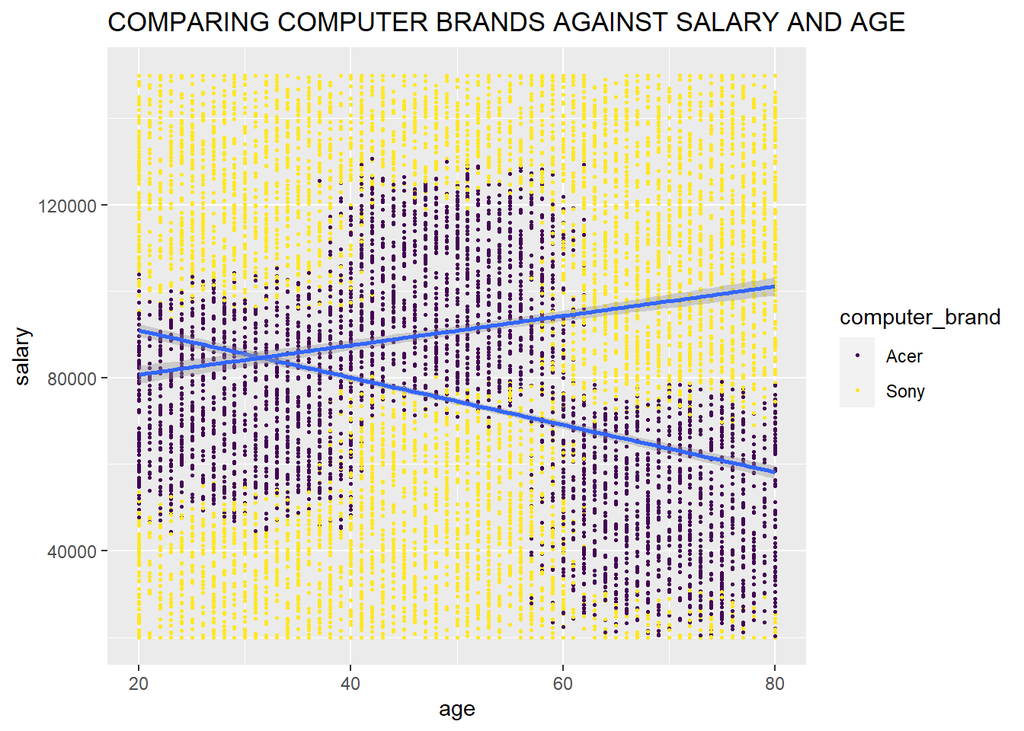

```r
    ggplot(completeResponses_Data, aes(age,salary))+
        geom_point(aes(color=computer_brand),size=0.5)+  geom_smooth(aes(age,salary,group=computer_brand),method = lm)+labs(title = "COMPARING COMPUTER BRANDS AGAINST SALARY AND AGE", x = "age", y = "salary")
```

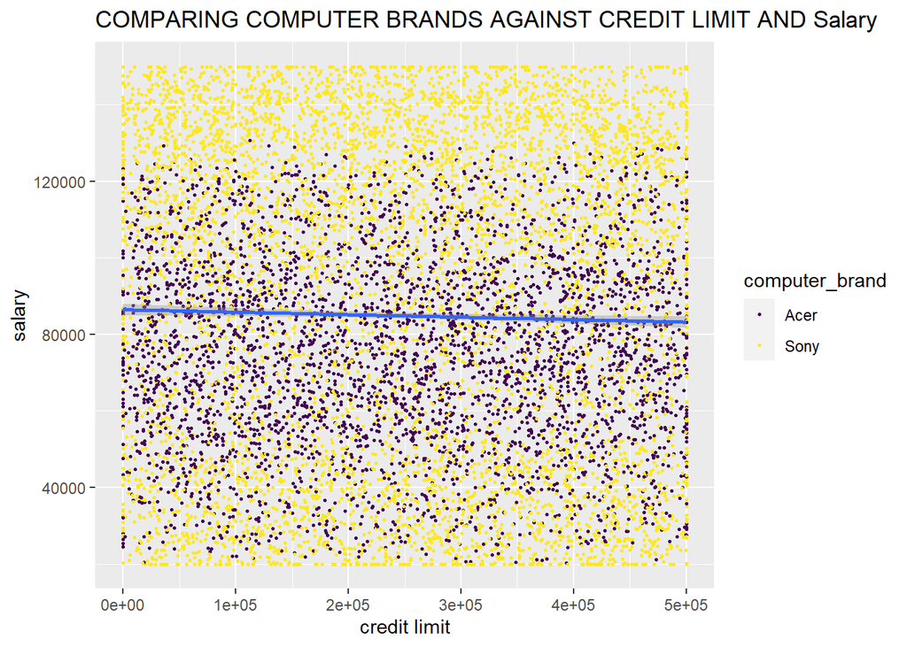

```r
    ggplot(completeResponses_Data, aes(credit,salary))+
        geom_point(aes(color=computer_brand),size=0.5)+  geom_smooth(aes(credit,salary),method = lm)+labs(title = "COMPARING COMPUTER BRANDS AGAINST CREDIT LIMIT AND Salary", x = "credit limit", y = "salary")
```

The ggplot of salary against credit limit shows a line of best fit that cuts across a wide-spread distribution. Due to the nature of the graph, it will be hard to make any deductions that could be helpful for our analysis.

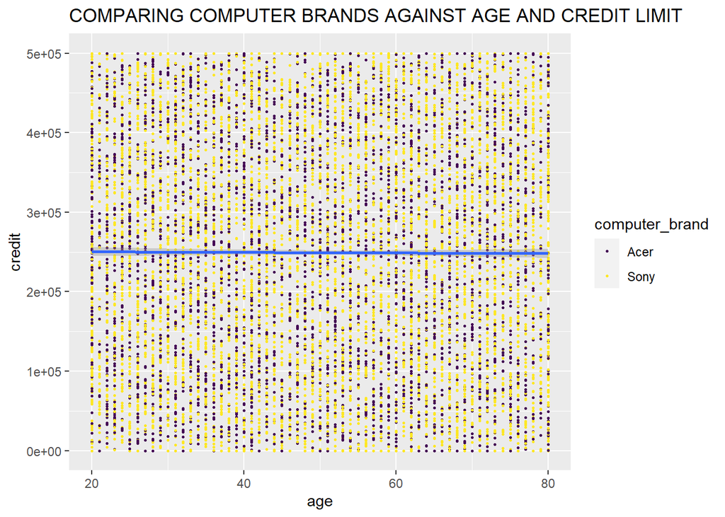

```r
ggplot(completeResponses_Data, aes(age,credit))+
  geom_point(aes(color=computer_brand),size=0.5) + geom_smooth(aes(age,credit),method = lm)+labs(title = "COMPARING COMPUTER BRANDS AGAINST AGE AND CREDIT LIMIT", x = "age", y = "credit")
```

Just like the previous graph, the line of best fit in the ggplot above cut through a graph with no clear differentiation of the values being plotted. This lets us know that credit limit and age together are not able to give strong indicators for a preferred computer brand.

So moving forward, we will be using salary against age to compare with other variables, as these two together gave a more informative ggplot.

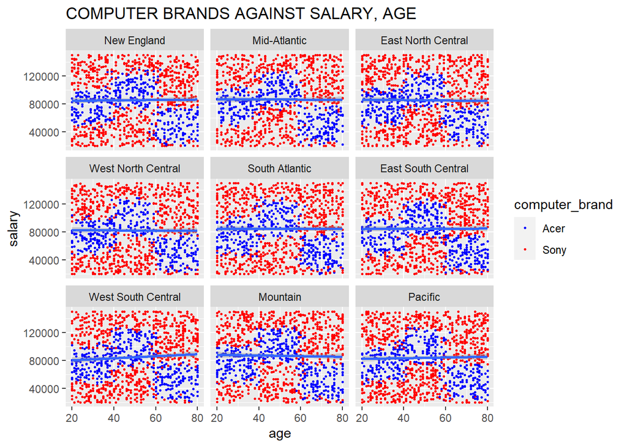

```r
ggplot(completeResponses_Data, aes(age, salary)) +
  geom_point(aes(color = computer_brand), size = 0.5) +
  geom_smooth(aes(age, salary), method = lm) +
  labs(title = "COMPUTER BRANDS AGAINST SALARY, AGE", x = "age", y = "salary") +
  facet_wrap(~ zipcode) +
  scale_color_manual(values = c("blue", "red"))
```

The above plot shows the salary against age graph across the different zipcodes. It is easy to note that there is no significant difference of the respective graphs. This confirms our previous deduction that zipcode does not significantly determine the computer brand purchased.

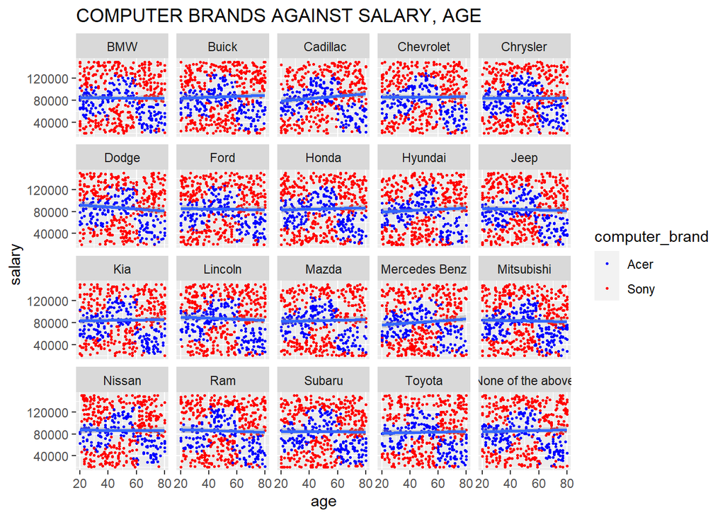

```r
ggplot(completeResponses_Data, aes(age, salary)) +
  geom_point(aes(color = computer_brand), size = 0.5) +
  geom_smooth(aes(age, salary), method = lm) +
  labs(title = "COMPUTER BRANDS AGAINST SALARY, AGE", x = "age", y = "salary") +
  facet_wrap(~ car) +
  scale_color_manual(values = c("blue", "red"))
```

We repeat the same plot we did with Zipcodes, this time with the car brands that customers have. And we notice the same thing. All the graphs look similiar. ANd this confirms our deduction in the previous section, that the type of car the customer drives does not determine the computer brand they are likely to purchase.

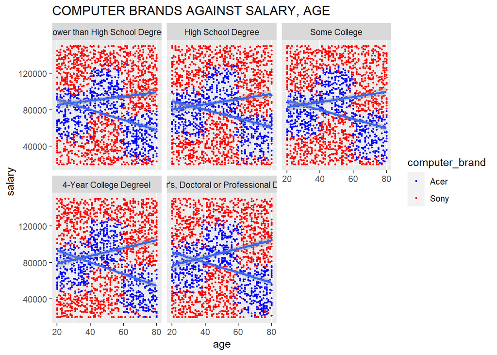

```r
ggplot(completeResponses_Data, aes(age, salary)) +
  geom_point(aes(color = computer_brand), size = 0.5) +
  geom_smooth(aes(age, salary, group=computer_brand), method = lm) +
  labs(title = "COMPUTER BRANDS AGAINST SALARY, AGE", x = "age", y = "salary") +
  facet_wrap(~ education_level)+
  scale_color_manual(values = c("blue", "red"))
```

And lastly, we repeat the process for education level. Again the graphs all look very similar. This further confirms our deduction that the customer’s education level does not determine the computer brand they are likely to purchase.

So far, from our EDA, we have found two values that determine the computer brand that a customer will buy. The two values are: Salary (the most powerful determiner) Age (Not as powerful as salary and is only significant when combined with the customer’s salary)

Next, we train our model.

# Training the Model

```r
set.seed(107)
isTrain <- createDataPartition(y = computer_brand,
                               p = .75,
                               list = FALSE)

trainingData <- completeResponses_Data[isTrain,]
testingData <- completeResponses_Data[-isTrain,]
```

```r
str(trainingData)
```

```
## 'data.frame':    7424 obs. of  7 variables:
##  $ salary         : num  119807 106880 78021 63690 50874 ...
##  $ age            : int  45 63 23 51 20 56 24 62 29 41 ...
##  $ education_level: Ord.factor w/ 5 levels "Lower than High School Degree"<..: 1 2 1 4 4 4 5 4 5 2 ...
##  $ car            : Ord.factor w/ 20 levels "BMW"<"Buick"<..: 14 11 15 6 14 14 8 3 17 5 ...
##  $ zipcode        : Ord.factor w/ 9 levels "New England"<..: 5 7 3 6 5 4 6 1 1 5 ...
##  $ credit         : num  442038 45007 48795 40889 352951 ...
##  $ computer_brand : Ord.factor w/ 2 levels "Acer"<"Sony": 1 2 1 2 1 2 2 2 1 2 ...
```

```r
cntrl <- trainControl(method = "repeatedcv", number = 10)
 #training data using a gradient boosting model
gbmFit <- train(computer_brand ~ .,
                data = trainingData,
                 method = "gbm",
                tuneLength = 7,
               trControl=cntrl,
               metric="Accuracy")
 saveRDS(gbmFit, "gbmFit1.RDS")
```

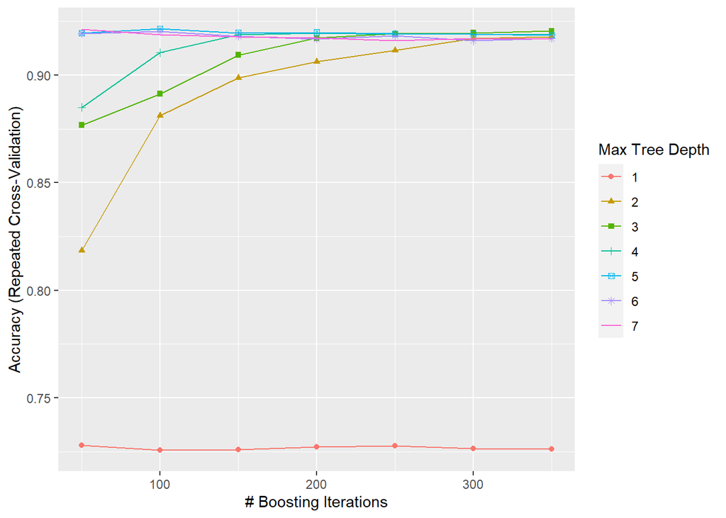

```r
ggplot(gbmFit) + theme(legend.position = "right")
```

```r
gbmBrands <- predict(gbmFit, newdata = testingData)
str(gbmBrands)
```

```
##  Ord.factor w/ 2 levels "Acer"<"Sony": 2 2 2 1 2 1 2 2 2 1 ...
```

```r
confusionMatrix(data = gbmBrands, testingData$computer_brand)
```

```
## Confusion Matrix and Statistics
##
##           Reference
## Prediction Acer Sony
##       Acer  854   84
##       Sony   82 1454
##
##                Accuracy : 0.9329
##                  95% CI : (0.9223, 0.9424)
##     No Information Rate : 0.6217
##     P-Value [Acc > NIR] : <2e-16
##
##                   Kappa : 0.8574
##
##  Mcnemar's Test P-Value : 0.9381
##
##             Sensitivity : 0.9124
##             Specificity : 0.9454
##          Pos Pred Value : 0.9104
##          Neg Pred Value : 0.9466
##              Prevalence : 0.3783
##          Detection Rate : 0.3452
##    Detection Prevalence : 0.3791
##       Balanced Accuracy : 0.9289
##
##        'Positive' Class : Acer
##
```

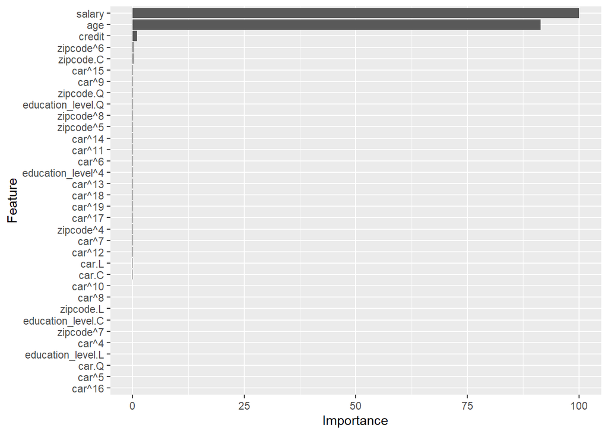

```r
importance <- varImp(gbmFit)
ggplot(importance)
```

For the Gradient Boosting Model, salary and age are the most important features. It has an accuracy of 0.9329 and a specificity of 0.9454

These are good. Next we check random tree.

```r
#MODEL II (RANDOM FOREST CLASSIFIER):
set.seed(107)

# training data using a random forest model
 rftFit <- train(computer_brand ~ .,
                data = trainingData,
                 method = "rf",
                tuneLength = 7,
               trControl=cntrl,
               metric="Accuracy")
```

```r
saveRDS(rftFit, "rftFit1.RDS")
```

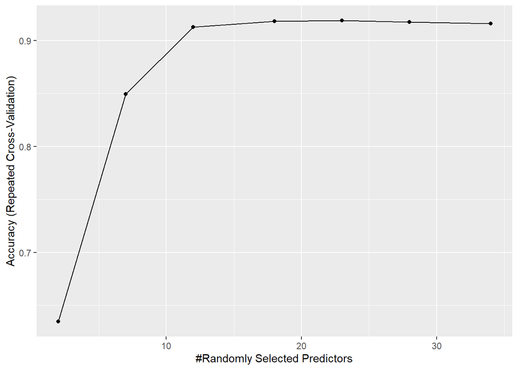

```r
rftFit <- readRDS("rftFit1.RDS")
ggplot(rftFit) + theme(legend.position = "top")
```

First, I allowed the compiler to automatically decide the mtry values for the Random Tree Classifier Model. Then plot the graph of accuracy against ‘Randomly Selected Predictors’

```r
mtry_vals <- c(2, 4, 6, 8, 10)

rftFit2 <- train(computer_brand ~ .,
                data = trainingData,
                 method = "rf",
                tuneGrid = data.frame(mtry = mtry_vals),
               trControl=cntrl,
               metric="Accuracy")
```

Next I manually selected 5 different mtry values (as seen in the code above) and then executed the code.

```r
saveRDS(rftFit2, "rftFit22.RDS")
```

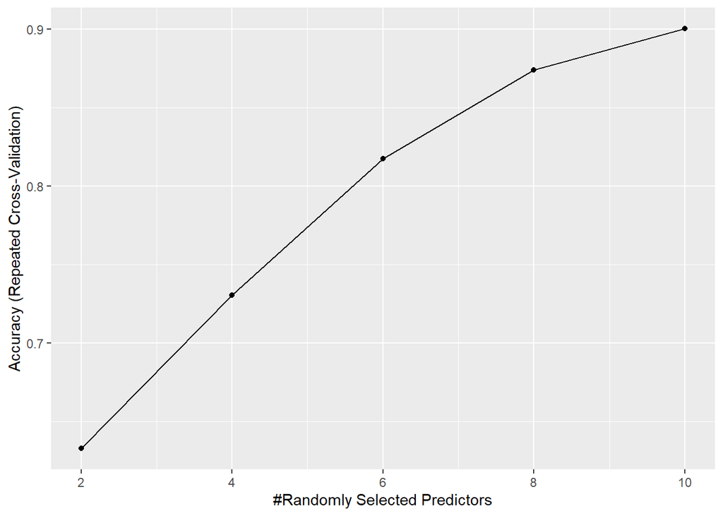

```r
rftFit2 <- readRDS("rftFit22.RDS")
ggplot(rftFit2, x="Manually Selected Predictors") + theme(legend.position = "right")
```

```r
predict_rfBrands <- predict(rftFit, newdata = testingData)
str(predict_rfBrands)
```

```
##  Ord.factor w/ 2 levels "Acer"<"Sony": 2 2 2 1 2 1 2 2 2 1 ...
```

```r
predict_rfBrands2 <- predict(rftFit2, newdata = testingData)
str(predict_rfBrands2)
```

```
##  Ord.factor w/ 2 levels "Acer"<"Sony": 2 2 2 2 2 1 2 2 2 1 ...
```

```r
confusionMatrix(data = predict_rfBrands, testingData$computer_brand)
```

```
## Confusion Matrix and Statistics
##
##           Reference
## Prediction Acer Sony
##       Acer  840   73
##       Sony   96 1465
##
##                Accuracy : 0.9317
##                  95% CI : (0.921, 0.9413)
##     No Information Rate : 0.6217
##     P-Value [Acc > NIR] : < 2e-16
##
##                   Kappa : 0.8541
##
##  Mcnemar's Test P-Value : 0.09059
##
##             Sensitivity : 0.8974
##             Specificity : 0.9525
##          Pos Pred Value : 0.9200
##          Neg Pred Value : 0.9385
##              Prevalence : 0.3783
##          Detection Rate : 0.3395
##    Detection Prevalence : 0.3690
##       Balanced Accuracy : 0.9250
##
##        'Positive' Class : Acer
##
```

```r
confusionMatrix(data = predict_rfBrands2, testingData$computer_brand)
```

```
## Confusion Matrix and Statistics
##
##           Reference
## Prediction Acer Sony
##       Acer  826  109
##       Sony  110 1429
##
##                Accuracy : 0.9115
##                  95% CI : (0.8996, 0.9224)
##     No Information Rate : 0.6217
##     P-Value [Acc > NIR] : <2e-16
##
##                   Kappa : 0.8118
##
##  Mcnemar's Test P-Value : 1
##
##             Sensitivity : 0.8825
##             Specificity : 0.9291
##          Pos Pred Value : 0.8834
##          Neg Pred Value : 0.9285
##              Prevalence : 0.3783
##          Detection Rate : 0.3339
##    Detection Prevalence : 0.3779
##       Balanced Accuracy : 0.9058
##
##        'Positive' Class : Acer
##
```

I performed a confusion matrix of both Random Forest with the Randomly selected predictors and my Mtry values. I noticed that the Random Forest with the Randomly Selected Predictors had a higher accuracy and a higher specificity. Hence moving forward, I will be comparing all other models with this one.

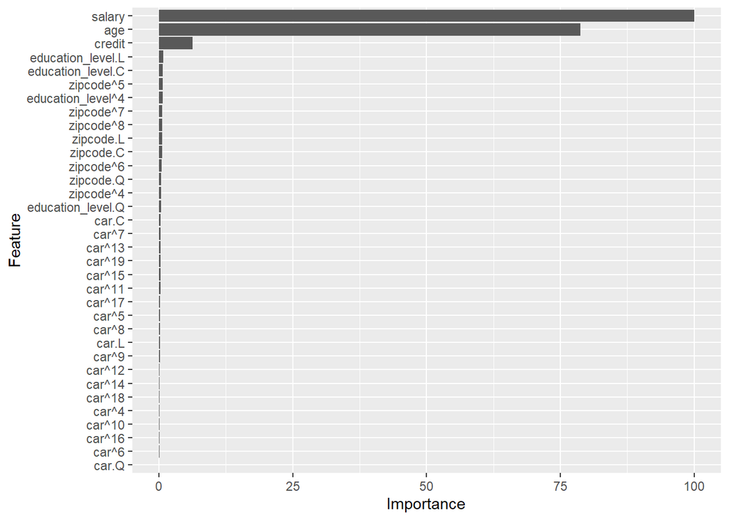

```r
importance_2 <- varImp(rftFit)
ggplot(importance_2)
```

For Random Forest, Salary is the most important feature, followed by age and lastly credit. Next we move to Decision Tree (c5) model.

```r
  set.seed(107)

  # training data using a c5.0 model
  c5Fit <- train(computer_brand ~ .,
                data = trainingData,
                 method = "C5.0",
                tuneLength = 7,
               trControl=cntrl,
               metric="Accuracy")
saveRDS(c5Fit, "c5Fit2.RDS")
```

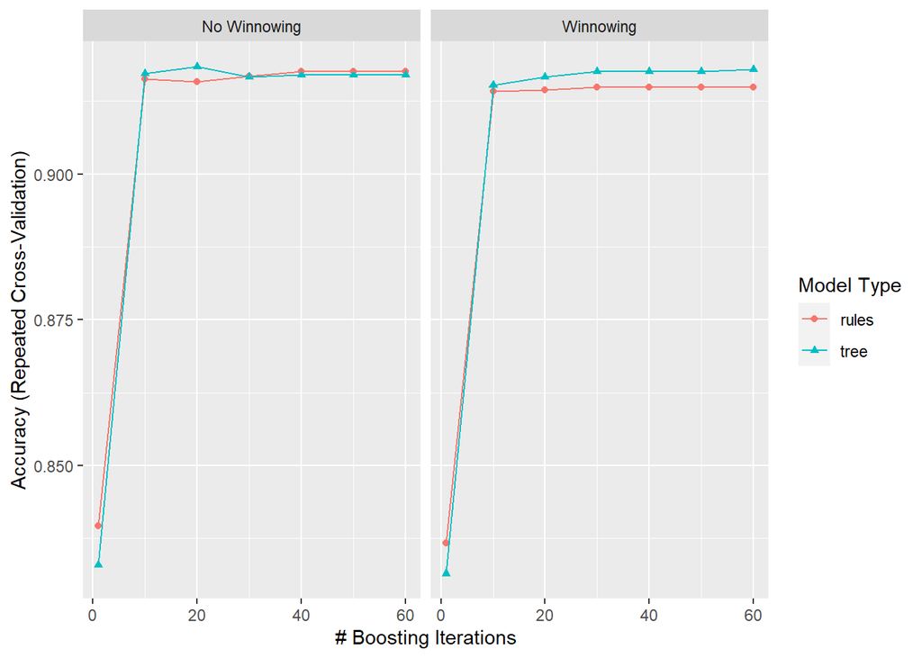

```r
 # read model from file
  c5Fit <- readRDS("c5Fit2.RDS")
ggplot(c5Fit) + theme(legend.position = "right")
```

```r
predit_c5Brands <- predict(c5Fit, newdata = testingData)
str(predit_c5Brands)
```

```
##  Ord.factor w/ 2 levels "Acer"<"Sony": 2 2 2 1 2 1 2 2 2 1 ...
```

```r
confusionMatrix(data = predit_c5Brands, testingData$computer_brand)
```

```
## Confusion Matrix and Statistics
##
##           Reference
## Prediction Acer Sony
##       Acer  845   93
##       Sony   91 1445
##
##                Accuracy : 0.9256
##                  95% CI : (0.9146, 0.9357)
##     No Information Rate : 0.6217
##     P-Value [Acc > NIR] : <2e-16
##
##                   Kappa : 0.842
##
##  Mcnemar's Test P-Value : 0.9412
##
##             Sensitivity : 0.9028
##             Specificity : 0.9395
##          Pos Pred Value : 0.9009
##          Neg Pred Value : 0.9408
##              Prevalence : 0.3783
##          Detection Rate : 0.3416
##    Detection Prevalence : 0.3791
##       Balanced Accuracy : 0.9212
##
##        'Positive' Class : Acer
##
```

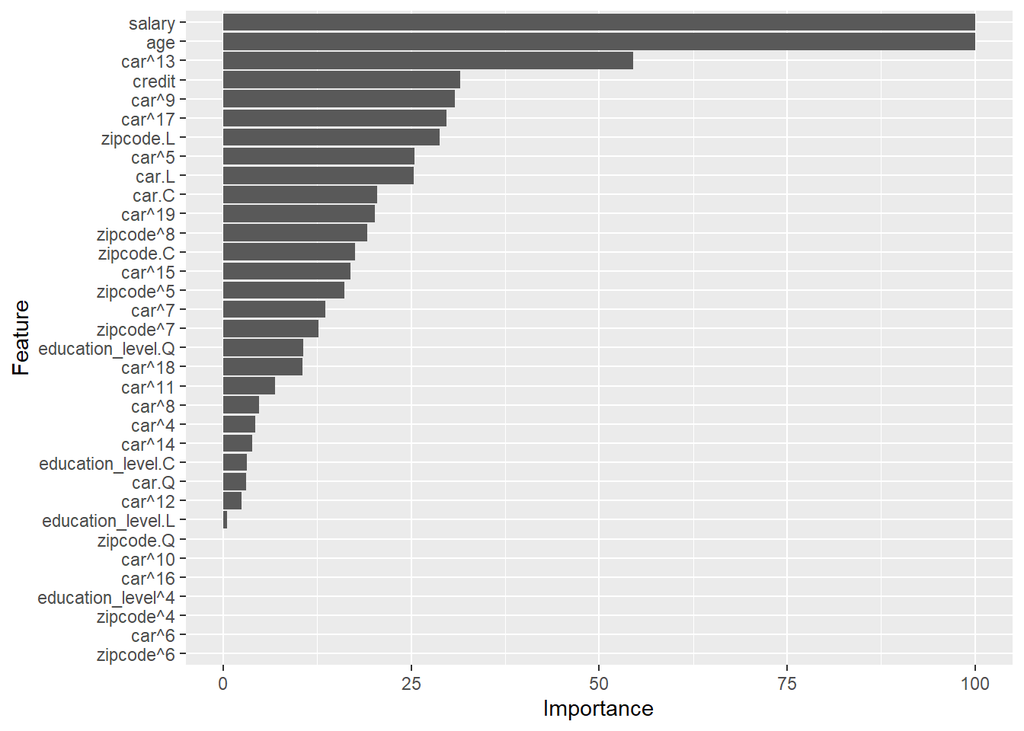

```r
importance2 <- varImp(c5Fit)
ggplot(importance2)
```

```r
#Now that we have performed all 3 models, we can compare the results to pick the best model:
resamps <- resamples(list(gbm = gbmFit, rf = rftFit, C5.0=c5Fit))
summary(resamps)
```

```
##
## Call:
## summary.resamples(object = resamps)
##
## Models: gbm, rf, C5.0
## Number of resamples: 10
##
## Accuracy
##           Min.   1st Qu.    Median      Mean   3rd Qu.      Max. NA's
## gbm  0.9110512 0.9141720 0.9225067 0.9214688 0.9269603 0.9340511    0
## rf   0.9098250 0.9168633 0.9192463 0.9187785 0.9219118 0.9258760    0
## C5.0 0.9057873 0.9130728 0.9171185 0.9183749 0.9229475 0.9326146    0
##
## Kappa
##           Min.   1st Qu.    Median      Mean   3rd Qu.      Max. NA's
## gbm  0.8109802 0.8187780 0.8358402 0.8336598 0.8448073 0.8602681    0
## rf   0.8081383 0.8219179 0.8295018 0.8272200 0.8332959 0.8432543    0
## C5.0 0.8005216 0.8152715 0.8251730 0.8266882 0.8359164 0.8570041    0
```

From the results above, gbm has the highest accuracy and the highest Kappa amongst all 3 model deployed. Also gbm took roughly te same amount of time as the other two models. So because of these reasons, I will be picking gbm as my best model and fine-tuning it.

```r
set.seed(107)


  cntrl2 <- trainControl(method = "repeatedcv", number = 10, repeats = 3)
 #perfecting the gradient boosting model
gbmFit_trained2 <- train(computer_brand ~ .,
                data = completeResponses_Data,
                 method = "gbm",
                tuneLength = 15,
               trControl=cntrl2,
               metric="Accuracy")
 saveRDS(gbmFit_trained2, "gbmFit_trained2.RDS")
```

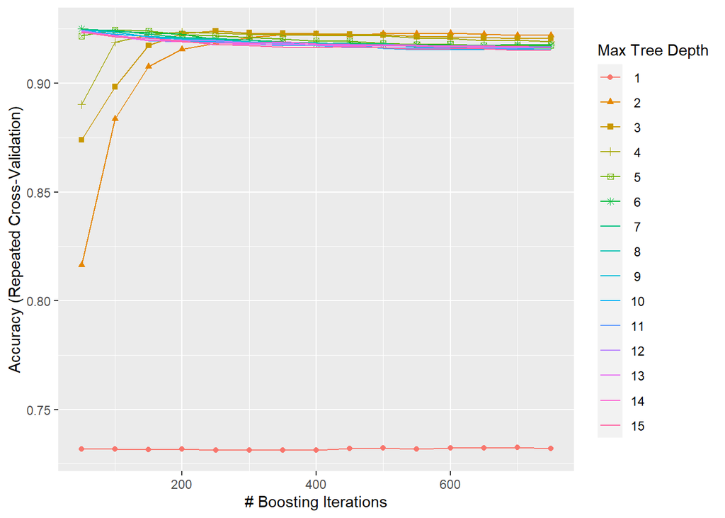

```r
gbmFit_trainedt <- readRDS("gbmFit_trained2.RDS")
ggplot(gbmFit_trainedt) + theme(legend.position = "right")
```

#Deploying the Trained Model

Now that we have selected our model and fine-tuned it, we can deploy it on the surveyIncomplete dateset.

But preliminary steps first.

We need to extract the surveyIncomplete data and then clean it up, where necessary.

```r
surveyIncomplete__data <- read.csv(file = './SurveyData/SurveyIncomplete.csv')
```

```r
head(surveyIncomplete__data)
```

```
##      salary age elevel car zipcode   credit brand
## 1 150000.00  76      1   3       3 377980.1     1
## 2  82523.84  51      1   8       3 141657.6     0
## 3 115646.64  34      0  10       2 360980.4     1
## 4 141443.39  22      3  18       2 282736.3     1
## 5 149211.27  56      0   5       3 215667.3     1
## 6  46202.25  26      4  12       1 150419.4     1
```

```r
#rowSums(is.na(completeResponsesData)) # Number of missing per row
nrow(surveyIncomplete__data[duplicated(surveyIncomplete__data),])
```

```
## [1] 0
```

```r
names(surveyIncomplete__data)<-c("salary","age","education_level","car","zipcode","credit","computer_brand")
```

```r
surveyIncomplete__data$education_level<-factor(surveyIncomplete__data$education_level,labels=c("Lower than High School Degree","High School Degree","Some College","4-Year College DegreeI","Master's, Doctoral or Professional Degree"),ordered=TRUE)

surveyIncomplete__data$car<-factor(surveyIncomplete__data$car,labels=c("BMW","Buick"," Cadillac","Chevrolet","Chrysler","Dodge","Ford","Honda","Hyundai","Jeep","Kia","Lincoln","Mazda","Mercedes Benz","Mitsubishi", "Nissan","Ram","Subaru","Toyota","None of the above"),ordered=TRUE)

surveyIncomplete__data$zipcode<-factor(surveyIncomplete__data$zipcode,labels=c("New England","Mid-Atlantic","East North Central","West North Central","South Atlantic", "East South Central" , "West South Central","Mountain","Pacific"),ordered=TRUE)

surveyIncomplete__data$computer_brand<-factor(surveyIncomplete__data$computer_brand,labels=c("Acer","Sony"),ordered=TRUE)
```

```r
predictBrands_gbmTrained <- predict(gbmFit_trainedt, newdata = surveyIncomplete__data)
# Replace the target variable in the data set
surveyIncomplete__data$computer_brand <- predictBrands_gbmTrained
```

In the code above, I replaced the target variable (computer_brands) with the predicted values from the fined-tuned gbm model.

```r
head(gbmFit_trainedt)
```

[output not shown]

[output cut: 616 more lines]

[output not shown]

```r
basic_eda(surveyIncomplete__data)
```

```
## Rows: 5,000
## Columns: 7
## $ salary          <dbl> 150000.00, 82523.84, 115646.64, 141443.39, 149211.27, …
## $ age             <int> 76, 51, 34, 22, 56, 26, 64, 50, 26, 46, 66, 76, 44, 42…
## $ education_level <ord> "High School Degree", "High School Degree", "Lower tha…
## $ car             <ord>  Cadillac, Honda, Jeep, Subaru, Chrysler, Lincoln, BMW…
## $ zipcode         <ord> West North Central, West North Central, East North Cen…
## $ credit          <dbl> 377980.10, 141657.61, 360980.36, 282736.32, 215667.29,…
## $ computer_brand  <ord> Sony, Acer, Sony, Sony, Sony, Sony, Sony, Sony, Sony, …
##          variable q_zeros p_zeros q_na p_na q_inf p_inf           type unique
## 1          salary       0    0.00    0    0     0     0        numeric   4877
## 2             age       0    0.00    0    0     0     0        integer     61
## 3 education_level       0    0.00    0    0     0     0 ordered-factor      5
## 4             car       0    0.00    0    0     0     0 ordered-factor     20
## 5         zipcode       0    0.00    0    0     0     0 ordered-factor      9
## 6          credit      68    1.36    0    0     0     0        numeric   4867
## 7  computer_brand       0    0.00    0    0     0     0 ordered-factor      2
```

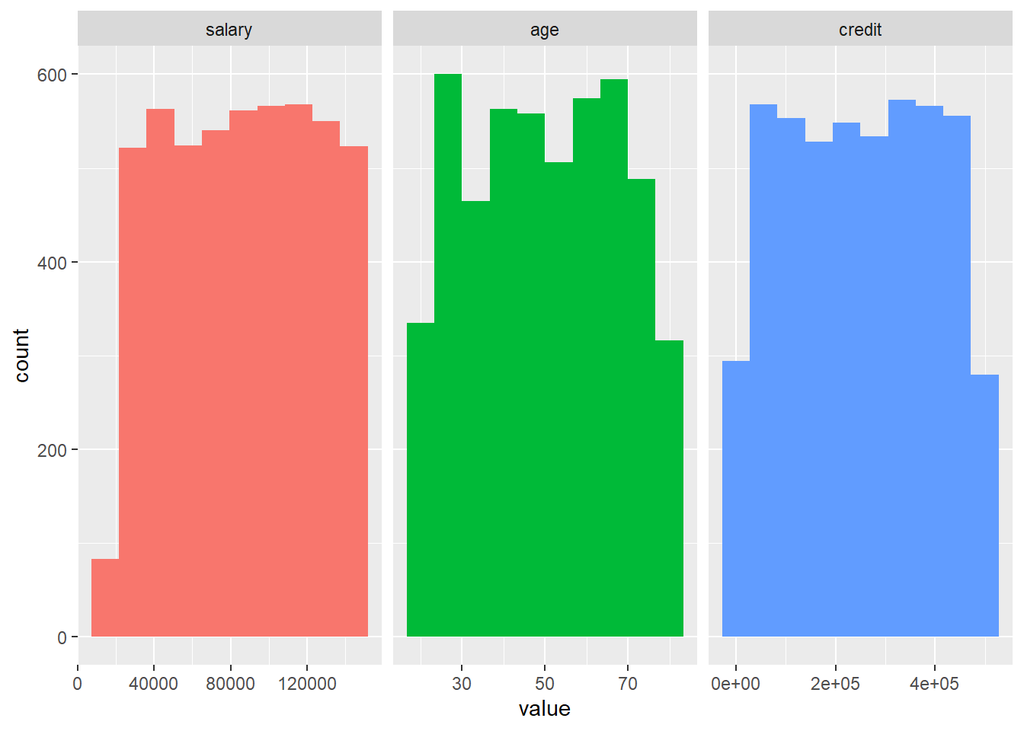